# Introduction

# Section 7 — Probability Mapping (Spatial Prediction of Enrichment)

In this section, we project the supervised model predictions back into geographic space. The goal is to visualize how the probability of enrichment varies across the sampled area.

This produces a spatial probability map that highlights:

- high‑probability enriched zones
- transitional geochemical gradients
- background regions

#### 7‑1 Scale the full dataset and predict probabilities

```python
# Scale the full dataset using the SAME scaler
X_all_scaled = scaler.transform(df[numeric_cols])

# Predict probability of enrichment for the entire dataset
prob_rf_all = rf.predict_proba(X_all_scaled)[:, 1]

# Add to dataframe
df["prob_enriched_rf"] = prob_rf_all
```

#### 7‑2 Probability Distribution (Histogram + KDE)

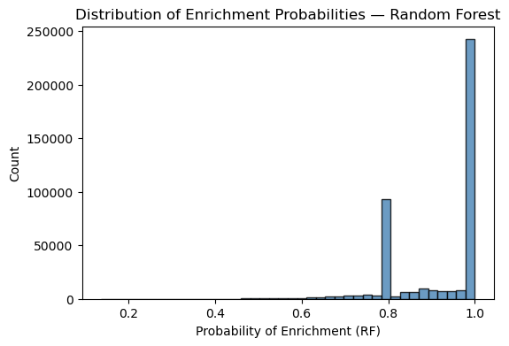

```python
plt.figure(figsize=(6, 4))
plt.hist(df["prob_enriched_rf"], bins=40, color="steelblue", edgecolor="k", alpha=0.8)
plt.xlabel("Probability of Enrichment (RF)")
plt.ylabel("Count")
plt.title("Distribution of Enrichment Probabilities — Random Forest")
plt.show()
```

#### 7‑3 Smoothed Probability Map (Gaussian Smoothing)

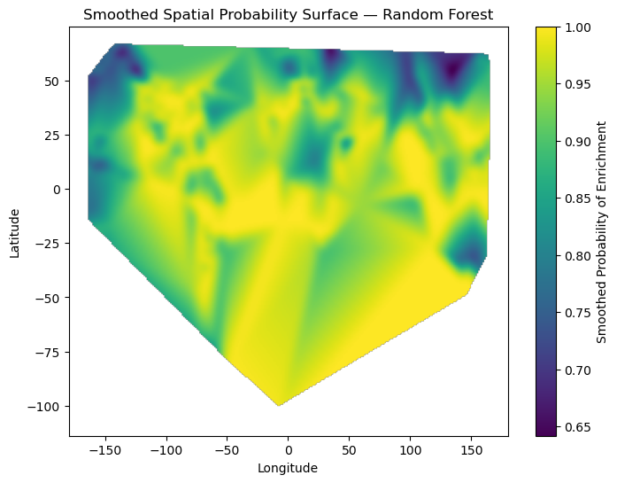

```python
from scipy.ndimage import gaussian_filter

# Create grid
lon_grid = np.linspace(df["LONGITUDE"].min(), df["LONGITUDE"].max(), 300)
lat_grid = np.linspace(df["LATITUDE"].min(), df["LATITUDE"].max(), 300)
lon_mesh, lat_mesh = np.meshgrid(lon_grid, lat_grid)

# Interpolate probabilities onto grid
from scipy.interpolate import griddata
prob_grid = griddata(
    points=df[["LONGITUDE", "LATITUDE"]].values,
    values=df["prob_enriched_rf"].values,
    xi=(lon_mesh, lat_mesh),
    method="linear"
)

# Smooth the grid
prob_grid_smooth = gaussian_filter(prob_grid, sigma=3)

plt.figure(figsize=(8, 6))
plt.imshow(
    prob_grid_smooth,
    extent=[lon_grid.min(), lon_grid.max(), lat_grid.min(), lat_grid.max()],
    origin="lower",
    cmap="viridis",
    aspect="auto"
)
plt.colorbar(label="Smoothed Probability of Enrichment")
plt.xlabel("Longitude")
plt.ylabel("Latitude")
plt.title("Smoothed Spatial Probability Surface — Random Forest")
plt.show()
```

#### 7‑4 Contour Map (Probability Isolines)

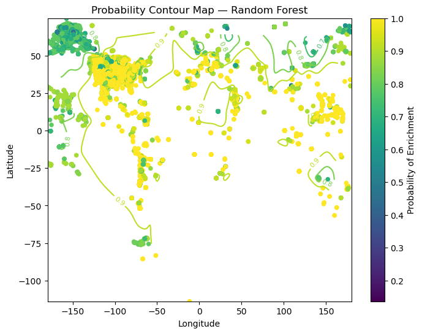

```python
plt.figure(figsize=(8, 6))

contours = plt.contour(
    lon_mesh, lat_mesh, prob_grid_smooth,
    levels=np.linspace(0, 1, 11),
    cmap="viridis"
)
plt.clabel(contours, inline=True, fontsize=8)

plt.scatter(df["LONGITUDE"], df["LATITUDE"], c=df["prob_enriched_rf"], cmap="viridis", s=20)
plt.colorbar(label="Probability of Enrichment")
plt.xlabel("Longitude")
plt.ylabel("Latitude")
plt.title("Probability Contour Map — Random Forest")
plt.show()
```

#### 7‑6 3D Probability Surface

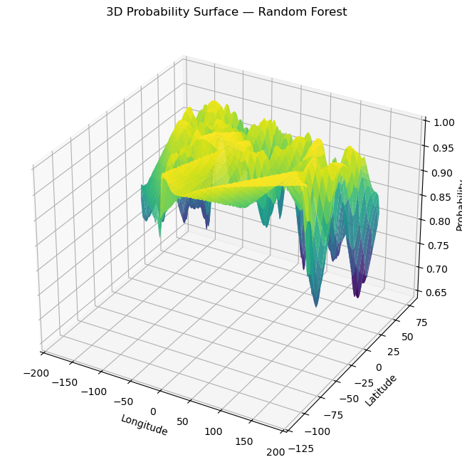

```python
from mpl_toolkits.mplot3d import Axes3D

fig = plt.figure(figsize=(12, 8))
ax = fig.add_subplot(111, projection="3d")

ax.plot_surface(
    lon_mesh, lat_mesh, prob_grid_smooth,
    cmap="viridis",
    edgecolor="none",
    alpha=0.9
)

ax.set_xlabel("Longitude")
ax.set_ylabel("Latitude")
ax.set_zlabel("Probability")
ax.set_title("3D Probability Surface — Random Forest")
plt.show()
```

# Section 8 — Integrated Geological Interpretation

The combined results from unsupervised clustering, supervised classification, and spatial probability mapping reveal a coherent and geologically meaningful enriched domain within the study area.

#### 1. Unsupervised Structure

The initial clustering (K-Means, PCA, and anomaly detection) identified a distinct geochemical cluster characterized by elevated concentrations of REEs, HFSEs, and pathfinder metals. This cluster forms a tight, internally consistent group, suggesting a shared geological process rather than random geochemical noise. The spatial distribution of these samples already hinted at a localized mineralized center.

Taken together, the results indicate that the enriched samples represent a genuine mineralized domain with strong internal coherence and predictable spatial behaviour. The geochemical signature—dominated by REEs, HFSEs, and pathfinder metals—suggests a system influenced by hydrothermal alteration, magmatic differentiation, or fluid-rock interaction processes. The spatial continuity and sharp probability gradients point toward a structurally or lithologically controlled mineralizing environment.

#### 5. Exploration Significance

The integrated workflow provides a robust, data-driven foundation for exploration targeting. The probability maps highlight areas where additional sampling, trenching, or geophysical surveys may be most effective. The consistency between unsupervised and supervised methods increases confidence in the anomaly and supports its interpretation as a meaningful geological feature rather than a statistical artifact.

## Next Steps for Exploration

The integrated geochemical and machine‑learning results provide a strong foundation for follow‑up exploration. The following steps are recommended to advance the geological understanding of the enriched zone and to refine targeting:

#### 1. Infill Geochemical Sampling

- sharpen the geochemical gradients
- confirm the continuity of the enriched zone
- help delineate potential structural or lithological controls

#### 2. Targeted Geological Mapping

Field mapping should focus on identifying features that could explain the geochemical footprint, such as:

- alteration zones (e.g., sericitic, potassic, or REE‑bearing assemblages)
- structural conduits (faults, shear zones, fractures)
- lithological contacts or intrusive centers

These observations will help link the geochemical anomaly to a geological process.

#### 3. Geophysical Surveys

Depending on the deposit style suggested by the geochemistry, geophysical methods can provide valuable subsurface context:

- **Magnetics** for mapping intrusive bodies or structural trends
- **Radiometrics** for alteration signatures or REE‑associated minerals
- **IP/Resistivity** for disseminated mineralization or alteration halos

Integrating geophysics with the probability surface can refine drill targeting.

### 4. Orientation Trenching or Shallow Drilling

If access and permitting allow, shallow subsurface testing across the high‑probability core can:

- validate the geochemical anomaly at depth
- identify mineralized structures or alteration zones
- provide material for petrography and geochemical characterization

This step is especially valuable if the anomaly is sharp and spatially coherent.

#### 5. Iterative Model Refinement

As new data are collected, the machine‑learning models should be retrained to:

- improve spatial prediction accuracy
- reduce uncertainty in transitional zones
- incorporate new geological or geophysical variables

This iterative loop strengthens both the geological model and the predictive power of the workflow.

#### 6. Regional‑Scale Application

Once validated, the workflow can be applied across the broader region to:

- identify additional anomalies with similar geochemical signatures
- map potential extensions of the mineralized system
- prioritize new target areas for follow‑up work

This transforms the project from a single‑anomaly study into a regional exploration tool.

# Summary (Unsupervised + Supervised Machine Learning)

This project integrates unsupervised and supervised machine‑learning methods to identify, characterize, and map a geochemically enriched domain within a large multielement dataset. Unsupervised techniques—PCA, K‑Means clustering, and anomaly detection—first revealed a distinct cluster of samples enriched in REEs, HFSEs, and key pathfinder metals. These enriched samples formed a tight, coherent group in multivariate space, displaying a focused spatial footprint that indicated a genuine geological process rather than statistical noise.

Together, the unsupervised and supervised results converge on a single interpretation: the enriched samples represent a coherent, spatially continuous mineralized domain with strong internal geochemical structure and clear exploration significance.